# Titanic Dataset Investigation

**This report will try to explore the Titanic dataset.This dataset contains 12 variables. According to the introduction of the dataset on Kaggle, the variables can be described as below:**

PassengerId: ID of passenger  
survival:Survival 0 = No, 1 = Yes  
pclass: Ticket class 1 = 1st, 2 = 2nd, 3 = 3rd  
Name: Name of passenger  
sex: Sex  
Age: Age in years  
sibsp: # of siblings / spouses aboard the Titanic  
parch: # of parents / children aboard the Titanic  
ticket: Ticket number  
fare: Passenger fare  
cabin: Cabin number  
embarked: Port of Embarkation C = Cherbourg, Q = Queenstown, S = Southampton Variable Notes

**Variable Notes**

pclass: A proxy for socio-economic status (SES)d  
1st = Upperd  
2nd = Middled  
3rd = Lowerd

age: Age is fractional if less than 1. If the age is estimated, is it in the form of xx.5d

sibsp: The dataset defines family relations in this way  
Sibling = brother, sister, stepbrother, stepsisterd  
Spouse = husband, wife (mistresses and fiancés were ignored)d

parch: The dataset defines family relations in this way  
Parent = mother, fatherd  
Child = daughter, son, stepdaughter, stepsond  
Some children travelled only with a nanny, therefore parch=0 for them.d

### Questions to Explore

**For this Titanic dataset, there are many interesting things to explore. First, there are three kind of ticket classes in Titanic. People with different ticket classes should stay in different location of Titanic and they may also have different difficulty levels of reaching life-saving equipment. Therefore, this report will first try to explore that do people in different ticket classes have different survivor rate？**

**Besides, many stories about Titanic show that many male passengers help female passengers and even give their own survive chances to the female passengers. This report will also try to explore that is this true?**

**In addition, people will different age may have different difficulty levels to survive during disasters. Does this also show in Titanic? This report will also explore how age affects survivor rate.**

**Also, people from the same family should be more likely to help each other than strangers, so dose the number of parents or children aboard the Titanic affects the survivor rate?**

**Finally, this report will also try to explore that do these variables have some correlations with each other?**

```python
import pandas as pd
import seaborn as sns
import matplotlib.pyplot as plt
%matplotlib inline
```

```python
titanic_data=pd.read_csv('titanic-data.csv')
```

```python
titanic_data.head()
```

|  | PassengerId | Survived | Pclass | Name | Sex | Age | SibSp | Parch | Ticket | Fare | Cabin | Embarked |
| --- | --- | --- | --- | --- | --- | --- | --- | --- | --- | --- | --- | --- |
| 0 | 1 | 0 | 3 | Braund, Mr. Owen Harris | male | 22.0 | 1 | 0 | A/5 21171 | 7.2500 | NaN | S |
| 1 | 2 | 1 | 1 | Cumings, Mrs. John Bradley (Florence Briggs Th... | female | 38.0 | 1 | 0 | PC 17599 | 71.2833 | C85 | C |
| 2 | 3 | 1 | 3 | Heikkinen, Miss. Laina | female | 26.0 | 0 | 0 | STON/O2. 3101282 | 7.9250 | NaN | S |
| 3 | 4 | 1 | 1 | Futrelle, Mrs. Jacques Heath (Lily May Peel) | female | 35.0 | 1 | 0 | 113803 | 53.1000 | C123 | S |
| 4 | 5 | 0 | 3 | Allen, Mr. William Henry | male | 35.0 | 0 | 0 | 373450 | 8.0500 | NaN | S |

```python
titanic_data.info()
```

```
<class 'pandas.core.frame.DataFrame'>
RangeIndex: 891 entries, 0 to 890
Data columns (total 12 columns):
PassengerId    891 non-null int64
Survived       891 non-null int64
Pclass         891 non-null int64
Name           891 non-null object
Sex            891 non-null object
Age            714 non-null float64
SibSp          891 non-null int64
Parch          891 non-null int64
Ticket         891 non-null object
Fare           891 non-null float64
Cabin          204 non-null object
Embarked       889 non-null object
dtypes: float64(2), int64(5), object(5)
memory usage: 83.6+ KB
```

### Data Wrangling

```python
titanic_data.isnull().sum()
```

```
PassengerId      0
Survived         0
Pclass           0
Name             0
Sex              0
Age            177
SibSp            0
Parch            0
Ticket           0
Fare             0
Cabin          687
Embarked         2
dtype: int64
```

**As we can see, there are 2 null values in Embarked column, 177 null values in age column and 687 null values in cabin column.**

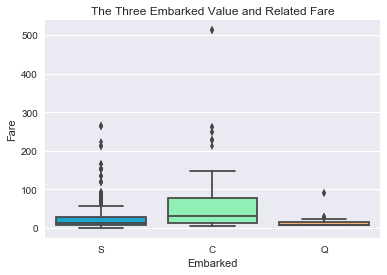

```python
sns.boxplot(x='Embarked',y='Fare',data=titanic_data,palette='rainbow')
plt.title('The Three Embarked Value and Related Fare')
```

```python
titanic_data[titanic_data['Embarked'].isnull()]
```

|  | PassengerId | Survived | Pclass | Name | Sex | Age | SibSp | Parch | Ticket | Fare | Cabin | Embarked |
| --- | --- | --- | --- | --- | --- | --- | --- | --- | --- | --- | --- | --- |
| 61 | 62 | 1 | 1 | Icard, Miss. Amelie | female | 38.0 | 0 | 0 | 113572 | 80.0 | B28 | NaN |
| 829 | 830 | 1 | 1 | Stone, Mrs. George Nelson (Martha Evelyn) | female | 62.0 | 0 | 0 | 113572 | 80.0 | B28 | NaN |

**As we can see, the two missing embarked values probably should be C. Since their fare are both 80 which may have some relationship with embarked values.**

```python
titanic_data.loc[titanic_data['Embarked'].isnull(),'Embarked']='C'
```

**For the 177 missing age, I'll delete the instances with the missing age.**

```python
titanic_data= titanic_data[titanic_data["Age"].notnull()]
```

**Since most cabin values are missing, it will not be helpful in this analysis. I'll delete this column**

```python
titanic_data = titanic_data.drop('Cabin', 1)
```

```python
titanic_data.info()
```

```
<class 'pandas.core.frame.DataFrame'>
Int64Index: 714 entries, 0 to 890
Data columns (total 11 columns):
PassengerId    714 non-null int64
Survived       714 non-null int64
Pclass         714 non-null int64
Name           714 non-null object
Sex            714 non-null object
Age            714 non-null float64
SibSp          714 non-null int64
Parch          714 non-null int64
Ticket         714 non-null object
Fare           714 non-null float64
Embarked       714 non-null object
dtypes: float64(2), int64(5), object(4)
memory usage: 66.9+ KB
```

### Data Analysis

**Now let's first explore how ticket class affect the survival rate.**

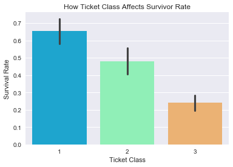

```python
sns.barplot(x='Pclass',y='Survived',data=titanic_data,palette='rainbow')
plt.title('How Ticket Class Affects Survivor Rate')
plt.ylabel('Survival Rate')
plt.xlabel('Ticket Class')
```

**As we can see, the first class have the highest survivor while the third class have the lowest survivor. Now let's check how sex affect survivor based on different ticket classes**

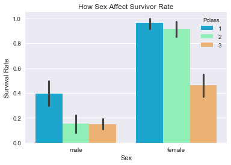

```python
sns.barplot(x='Sex',y='Survived',data=titanic_data,palette='rainbow',hue="Pclass")
plt.title('How Sex Affect Survivor Rate')
plt.ylabel('Survival Rate')
plt.xlabel('Sex')
```

**As we can see, for male, the first class has much more survivors compared with the second and the third classes. The survivor count of the second and the third classes are similar. For female, the first class has little higher survivors count compared with the second class. The first and the second classes have much more survivors compared with the third classes.**

**Now let's check the influence of age. Let's visualize the survivors' ages.**

```python
survivors_ages_female = titanic_data[(titanic_data["Survived"] == 1) & (titanic_data["Sex"] == "female")]["Age"]
survivors_ages_male = titanic_data[(titanic_data["Survived"] == 1) & (titanic_data["Sex"] == "male")]["Age"]
```

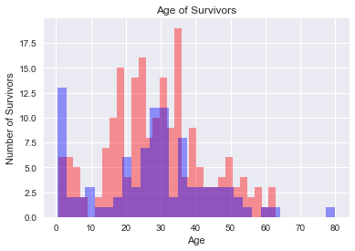

```python
sns.distplot(survivors_ages_female,bins=30,kde=False,color='red')
sns.distplot(survivors_ages_male,bins=30,kde=False,color='blue')
plt.title('Age of Survivors')
plt.ylabel('Number of Survivors')
```

**As we can see, most female survivor's ages are around 15-40. Most male survivors' age are around 20-30. There're also many male babies survivors.**

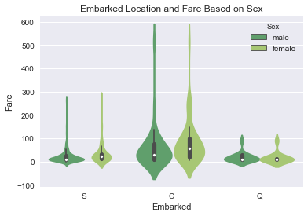

```python
sns.violinplot(x='Embarked',y='Fare',data=titanic_data,palette='summer',hue='Sex')
plt.title('Embarked Location and Fare Based on Sex')
```

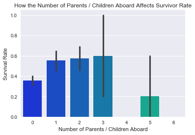

```python
sns.barplot(x='Parch',y='Survived',data=titanic_data,palette='winter')
plt.title('How the Number of Parents / Children Aboard Affects Survivor Rate')
plt.ylabel('Survival Rate')
plt.xlabel('Number of Parents / Children Aboard')
```

**We can also check the correlation among the variables with heatmap.**

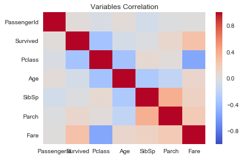

```python
sns.heatmap(titanic_data.corr(),cmap='coolwarm')
plt.title('Variables Correlation')
```

**As we can see from the heatmap, the ticket class and Passenger fare do have some relationship with whether a person can be survived or not. The better the ticket class, the higher the survivor rate. The higher the ticket fare, the higher the survivor rate. We also find that parch has some positive influence on survivor rate.**

## summary

**However, there may be still many factors behind the data and many unexploied situations. This report still has many limitations. For furthur study, deeper machine learning methods should be involved in the research. The survival rate should be better quantified and more analysis methods should be involved in the divided training and testing dataset.**